# SOC/CSSS/CSDE 533 Lab 2

Sarah Kilpatrick

2025-01-27

# Problem 1: Data and Scatterplots - 50 points

*Install and load the package `wpp2024` into your `R` environment.*

*Load the datasets `e0F1` and `e0M1`. Note:* $e_0$ *is demographic notation for life expectancy at birth, or how many years, on average, a person from a specific population can expect to live. These estimates are typically made separately for two sex categories: male and female, as there is a known gap between male and female life expectancy.*

```r
data(`e0F1`)
data(`e0M1`)
```

**(a)5 points** Use several functions we’ve discussed to ‘get to know your data’. HINT: don’t forget to use the help documentation for the datasets/package.

1. *Who published these life expectancy estimates? When were they published?*

Reference: World Population Prospects: The 2024 Revision. http://population.un.org/wpp

Details: These data come from the United Nations’ annual and 5-year time series of the life expectancy at birth (e0) for all countries of the world as available in 2024.

“These datasets are based on estimates and projections of United Nations, Department of Economic and Social Affairs, Population Division (2024). The pre-1950 datasets and the 5-year datasets were compiled by Patrick Gerland.”

2. *What class of object is the second column of `e0F1`?*

The second column of `e0F1` is a character column called ‘name’.

3. *What is the range of female and male life expectancy for the 2023 time period? Present your results in a table.*

```r
output = data.frame(
  Gender = c("Female", "Male"),
  Min_Life_Expectancy = c(min(e0F1$`2023`, na.rm = TRUE), min(e0M1$`2023`, na.rm = TRUE)),
  Max_Life_Expectancy = c(max(e0F1$`2023`, na.rm = TRUE), max(e0M1$`2023`, na.rm = TRUE))
)

kable(output,
      col.names = c("Gender", "Minimum Life Expectancy in Years", "Maximum Life Expectancy in Years"),
      digits = 2,
      caption = "Range of Female/Male Life Expectancy in 2023") %>%
  kable_styling(
    font_size = 15
  )
```

Range of Female/Male Life Expectancy in 2023

| Gender | Minimum Life Expectancy in Years | Maximum Life Expectancy in Years |
| --- | --- | --- |
| Female | 54.74 | 88.50 |
| Male | 53.20 | 84.45 |

**(c)10 points** Pick a country of your choice and plot both male and female life expectancy against time.

Join the data for plotting and later use:

```r
paraguay_long_female = paraguay_long_female %>%
  mutate(Gender = "Female")
paraguay_long_male = paraguay_long_male %>%
  mutate(Gender = "Male")

joined_paraguay_data = bind_rows(paraguay_long_female, paraguay_long_male)

joined_paraguay_data$Year = as.numeric(joined_paraguay_data$Year)
```

Plot the data:

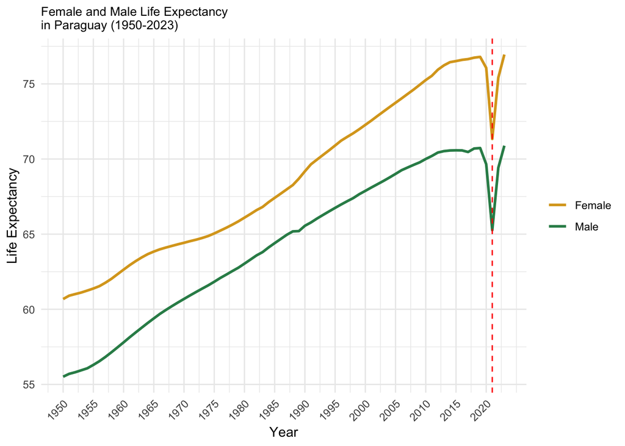

```r
ggplot(joined_paraguay_data, aes(x = Year, y = e_0, color = Gender)) +
  geom_line(linewidth = 1) +
  ggtitle("Female and Male Life Expectancy\nin Paraguay (1950-2023)") +
  xlab("Year") +
  ylab("Life Expectancy") +
  scale_color_manual(values = c("goldenrod", "seagreen")) +
  scale_x_continuous(breaks = seq(min(joined_paraguay_data$Year), max(joined_paraguay_data$Year), by = 5)) +
geom_vline(xintercept = 2021, linetype = "dashed", color = "red", linewidth = 0.5) +
theme_minimal() +
theme(
    axis.text.x = element_text(angle = 45, hjust = 1),
    plot.title = element_text(size = 10),
    legend.title = element_blank()
  )
```

There’s a sharp drop in 2021 marked with a red dashed line. This was likely due to the COVID-19 pandemic. Paraguay’s response to the pandemic in 2020 and 2021 was to focus on sanitation, exposure tracking, and a multi-phase return to school/work plan beginning in October 2020.

Even with the onset of vaccinations in early 2021, that year experienced the maximum amount of deaths and infections between 2020 and when they stopped tracking this information in March of 2022. This information was found through the [Paraguayan Government’s Department of Public Health and Wellness](https://www.mspbs.gov.py/index.php).

1. *Use a combination of `plot` and `points` to make a scatterplot of* $e_0$ *versus time. Use either distinct symbols OR distinct colors for each sex, and include a legend. Use the axis labels and title to correctly annotate your plot.*

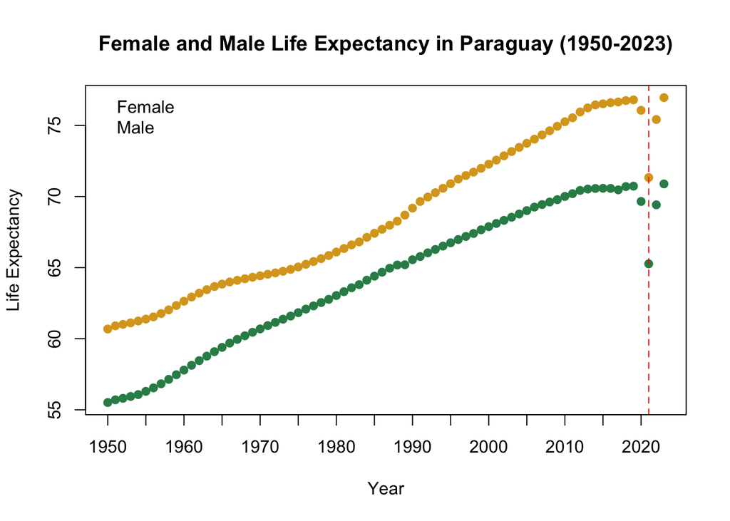

```r
plot(joined_paraguay_data$Year, joined_paraguay_data$e_0,
     type = "n",
     xlab = "Year", ylab = "Life Expectancy",
     main = "Female and Male Life Expectancy in Paraguay (1950-2023)",
     xaxt = "n",
     xlim = c(min(joined_paraguay_data$Year), max(joined_paraguay_data$Year)),
     ylim = c(min(joined_paraguay_data$e_0), max(joined_paraguay_data$e_0)))

points(joined_paraguay_data$Year[joined_paraguay_data$Gender == "Female"],
       joined_paraguay_data$e_0[joined_paraguay_data$Gender == "Female"],
       col = "goldenrod", pch = 19)

points(joined_paraguay_data$Year[joined_paraguay_data$Gender == "Male"],
       joined_paraguay_data$e_0[joined_paraguay_data$Gender == "Male"],
       col = "seagreen", pch = 19)

# Dashed red line at x = 2021
abline(v = 2021, col = "red", lty = 2, lwd = 1)

axis(1, at = seq(min(joined_paraguay_data$Year), max(joined_paraguay_data$Year), by = 5))

# Legend
legend("topleft", legend = c("Female", "Male"),
       col = c("goldenrod", "seagreen"), bty = "n")
```

2. *Use `?lines` or `help("lines")` to look up the documentation for the function `lines`. Use a combination of `plot` and `lines` to plot the male and female life expectancies from your country of choice. (Your plot should not contain individual points, but two distinct lines.) Use either color or line type to distinguish between the series for each sex. Include a legend and appropriate axis labels and a main title. Save this plot as a .pdf.*

```r
?lines
```

Save the PDF:

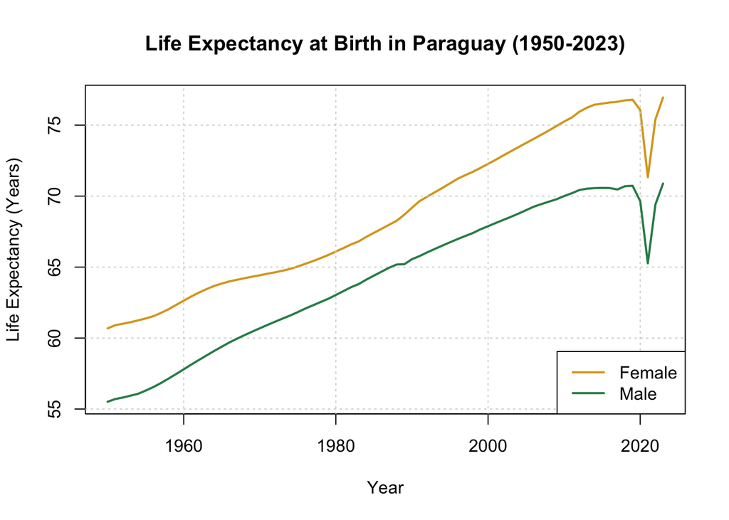

```r
# # Save the plot as a PDF
# pdf("paraguay_e0_lines.pdf",
#     width = 6, height = 6)

plot(paraguay_long_female$Year, paraguay_long_female$e_0,
     type = "l",
     col = "goldenrod",
     lwd = 2,
     xlab = "Year",
     ylab = "Life Expectancy (Years)",
     main = "Life Expectancy at Birth in Paraguay (1950-2023)",
     ylim = range(min(paraguay_long_male$e_0), max(paraguay_long_female$e_0)))

#grid lines
grid(nx = NULL, ny = NULL, col = "lightgray")

lines(paraguay_long_male$Year, paraguay_long_male$e_0,
      col = "seagreen",
      lwd = 2)

legend("bottomright",
       legend = c("Female", "Male"),
       col = c("goldenrod", "seagreen"),
       lwd = 2)
```

```r
dev.off() #turn off graphical device function off
```

Plot the lines

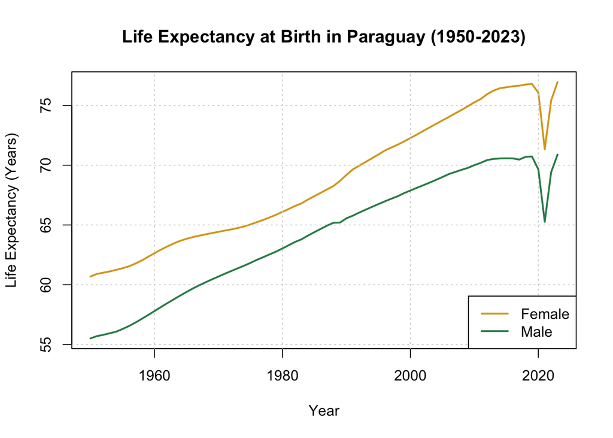

```r
plot(paraguay_long_female$Year, paraguay_long_female$e_0,
     type = "l",
     col = "goldenrod",
     lwd = 2,
     xlab = "Year",
     ylab = "Life Expectancy (Years)",
     main = "Life Expectancy at Birth in Paraguay (1950-2023)",
     ylim = range(min(paraguay_long_male$e_0), max(paraguay_long_female$e_0)))

#grid lines
grid(nx = NULL, ny = NULL, col = "lightgray")

lines(paraguay_long_male$Year, paraguay_long_male$e_0,
      col = "seagreen",
      lwd = 2)

legend("bottomright",
       legend = c("Female", "Male"),
       col = c("goldenrod", "seagreen"),
       lwd = 2)
```

**(d)20 points** Create a new data frame called `plot_data` by subsetting `e0F1` and selecting 4 countries and the row whose `country_code == 900` and `name = "World"`.

I am choosing the 4 countries that had the highest frequency of tropical cyclones in 2024. These rankings vary by source but [this article](https://www.newsweek.com/map-shows-which-countries-get-most-hurricanes-1965603) was reported by Newsweek, provided by the Weather Channel.

1. China
2. Philippines
3. Japan
4. Mexico

| country_code | name | 1950 | 1951 | 1952 | 1953 | 1954 | 1955 | 1956 | 1957 | 1958 | 1959 | 1960 | 1961 | 1962 | 1963 | 1964 | 1965 | 1966 | 1967 | 1968 | 1969 | 1970 | 1971 | 1972 | 1973 | 1974 | 1975 | 1976 | 1977 | … |
| --- | --- | --- | --- | --- | --- | --- | --- | --- | --- | --- | --- | --- | --- | --- | --- | --- | --- | --- | --- | --- | --- | --- | --- | --- | --- | --- | --- | --- | --- | --- |
| 900 | World | 48.44 | 49.04 | 49.97 | 50.51 | 51.33 | 51.94 | 52.48 | 52.82 | 53.41 | 51.38 | 49.60 | 52.19 | 55.13 | 55.62 | 56.21 | 56.08 | 56.57 | 57.10 | 57.67 | 58.06 | 58.29 | 58.42 | 59.31 | 59.81 | 60.22 | 60.48 | 60.74 | 61.39 | … |
| 156 | China | 45.73 | 46.40 | 47.21 | 47.65 | 48.57 | 49.23 | 49.79 | 50.40 | 50.93 | 41.98 | 34.86 | 41.90 | 53.19 | 53.87 | 54.53 | 55.22 | 55.80 | 56.50 | 57.23 | 57.99 | 58.78 | 59.60 | 60.47 | 61.48 | 62.35 | 63.11 | 63.28 | 64.67 | … |
| 392 | Japan | 60.88 | 62.61 | 64.67 | 65.07 | 66.57 | 67.77 | 67.67 | 67.62 | 69.31 | 69.78 | 70.14 | 70.83 | 71.14 | 72.28 | 72.76 | 72.85 | 73.65 | 73.99 | 74.28 | 74.63 | 74.68 | 75.48 | 75.94 | 76.02 | 76.37 | 76.87 | 77.29 | 77.86 | … |
| 608 | Philippines | 54.77 | 55.28 | 55.97 | 56.75 | 57.38 | 57.91 | 58.66 | 59.33 | 59.93 | 60.47 | 61.11 | 61.50 | 61.89 | 62.16 | 62.33 | 62.71 | 63.01 | 63.30 | 63.48 | 63.64 | 63.49 | 63.81 | 63.73 | 63.63 | 63.73 | 63.86 | 63.77 | 64.46 | … |
| 484 | Mexico | 45.45 | 46.43 | 47.39 | 48.69 | 49.87 | 51.11 | 51.83 | 52.65 | 53.39 | 54.29 | 55.29 | 55.89 | 56.54 | 57.05 | 57.71 | 58.66 | 59.36 | 60.26 | 60.42 | 60.57 | 60.84 | 61.40 | 62.06 | 62.79 | 63.62 | 64.52 | 65.19 | 65.86 | … |

1. *Convert your new data.frame from **wide** format (one row per country) to **long** format (a row for every country/year period). In `tidyr` this is done using `pivot_longer`. In base R this is done using `reshape`. Use both `pivot_longer` and `reshape`.*

```r
cyclone_data_long <- plot_data %>%
  pivot_longer(
    # Specify the columns from years 1951 to 2023
    cols = `1950`:`2023`,
    # name of new SINGLE column for year from MANY columns
    names_to = "Year",
    # name of new column for life expectancy values
    values_to = "e_0"
  )

kable(cyclone_data_long,
      col.names = c("Country Code", "Country Name", "Year", "Female Life Expectancy at Birth"),
      digits = 2,
      caption = "Long Format of plot_data: Top 4 Cyclone-Prone Nations (2024) vs. World") %>%
  kable_styling(
    font_size = 15
  ) %>%
  scroll_box(width = "900px", height = "500px")
```

Long Format of plot_data: Top 4 Cyclone-Prone Nations (2024) vs. World

| Country Code | Country Name | Year | Female Life Expectancy at Birth |
| --- | --- | --- | --- |
| 900 | World | 1950 | 48.44 |
| 900 | World | 1951 | 49.04 |
| 900 | World | 1952 | 49.97 |
| 900 | World | 1953 | 50.51 |
| 900 | World | 1954 | 51.33 |
| 900 | World | 1955 | 51.94 |
| 900 | World | 1956 | 52.48 |
| 900 | World | 1957 | 52.82 |
| 900 | World | 1958 | 53.41 |
| 900 | World | 1959 | 51.38 |
| 900 | World | 1960 | 49.60 |
| 900 | World | 1961 | 52.19 |
| 900 | World | 1962 | 55.13 |
| 900 | World | 1963 | 55.62 |
| 900 | World | 1964 | 56.21 |
| 900 | World | 1965 | 56.08 |
| 900 | World | 1966 | 56.57 |
| 900 | World | 1967 | 57.10 |
| 900 | World | 1968 | 57.67 |
| 900 | World | 1969 | 58.06 |
| 900 | World | 1970 | 58.29 |
| 900 | World | 1971 | 58.42 |
| 900 | World | 1972 | 59.31 |
| 900 | World | 1973 | 59.81 |
| 900 | World | 1974 | 60.22 |
| 900 | World | 1975 | 60.48 |
| 900 | World | 1976 | 60.74 |
| 900 | World | 1977 | 61.39 |
| 900 | World | 1978 | 61.80 |
| 900 | World | 1979 | 62.49 |

[output cut: 340 more lines]

2. *How do the two functions differ in their output?*

The tidyverse function pivot_longer() outputs a tibble, while the base R reshape() function outputs a basic R dataframe. Tibbles tend to be more human-readable with cleaner presentation, but are not very different from R dataframes just from appearance alone. A bigger difference is the way the two functions differ in treating variables: the tidyverse’s output won’t make the new column values into factors like the base R’s function will.

3. *Create table showing the min, mean, and max life expectancies for each population in your dataset.*

```r
# Subsetting data for each country and population group
china_long <- subset(cyclone_data_long, name == "China")
philippines_long <- subset(cyclone_data_long, name == "Philippines")
japan_long <- subset(cyclone_data_long, name == "Japan")
mexico_long <- subset(cyclone_data_long, name == "Mexico")
world_long <- subset(cyclone_data_long, name == "World")

pop_list <- list(china_long, philippines_long, japan_long, mexico_long, world_long)

# place to store the new data
summary_e0_table <- data.frame(
  name = character(0),
  `minimum e_0` = numeric(0),
  `maximum e_0` = numeric(0),
  `average e_0` = numeric(0)
)

for (populationn in pop_list) {
  pop_name <- unique(populationn$name)
  min_e0 <- min(populationn$e_0, na.rm = TRUE)
  max_e0 <- max(populationn$e_0, na.rm = TRUE)
  mean_e0 <- mean(populationn$e_0, na.rm = TRUE)

  summary_e0_table <- rbind(summary_e0_table,
                            data.frame(name = pop_name,
                                       `minimum e_0` = min_e0,
                                       `maximum e_0` = max_e0,
                                       `average e_0` = mean_e0))
}

kable(summary_e0_table,
      col.names = c("Country Name", "e_0 Minimum", "e_0 Maximum","e_0 Average"),
      digits = 2,
      caption = "Female Life Expectancy at Birth in Years: Top 4 Cyclone-Prone Nations (2024) vs. World") %>%
  kable_styling(font_size = 15)
```

Female Life Expectancy at Birth in Years: Top 4 Cyclone-Prone Nations (2024) vs. World

| Country Name | e_0 Minimum | e_0 Maximum | e_0 Average |
| --- | --- | --- | --- |
| China | 34.86 | 81.13 | 66.51 |
| Philippines | 54.77 | 73.42 | 66.61 |
| Japan | 60.88 | 87.74 | 79.21 |
| Mexico | 45.45 | 77.81 | 67.31 |
| World | 48.44 | 75.89 | 63.97 |

**(e)15 points** Choose one of the long format data.frames you just created. Use `ggplot + geom_line()` to create a plot of female life expectancy against time by the 5 regions (4 countries + world) in your dataset. Print the plot in our output **AND** save this plot as a .pdf. Comment on how the life expectancy trajectories of the four countries you chose compare to the overall trajectory of life expectancy across the World?

```r
# Save the plot as a PDF
pdf("cyclone_e0_plot.pdf",
    width = 6, height = 6)

cyclone_data_long$Year <- as.numeric(cyclone_data_long$Year)

ggplot(cyclone_data_long, aes(x = Year, y = e_0, color = name)) +
  geom_line(size = 1) +
  labs(
    title = "Female Life Expectancy Over Time: Cyclone-Prone Nations vs. World",
    x = "Year",
    y = "Life Expectancy at Birth (Years)",
    color = "Country"
  ) +
  scale_color_manual(values = c("chocolate", "goldenrod", "seagreen", "steelblue", "slateblue")) +
  scale_x_continuous(breaks = seq(min(cyclone_data_long$Year), max(cyclone_data_long$Year), by = 5)) +
  theme_minimal() +
  theme(
    plot.title = element_text(size = 10),
    axis.text.x = element_text(angle = 45, hjust = 1)
  )
dev.off()
```

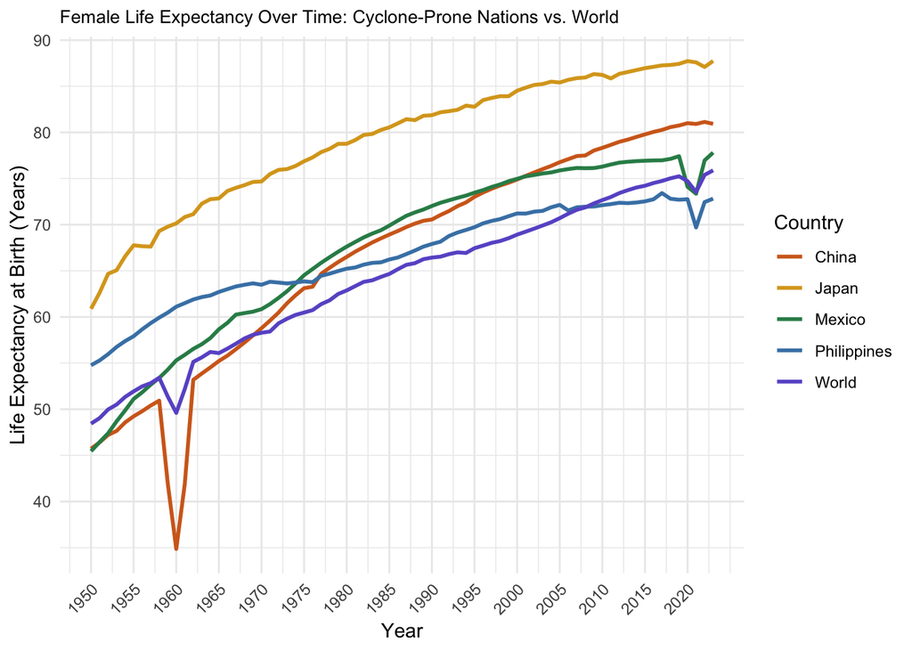

```r
cyclone_data_long$Year <- as.numeric(cyclone_data_long$Year)

ggplot(cyclone_data_long, aes(x = Year, y = e_0, color = name)) +
  geom_line(size = 1) +
  labs(
    title = "Female Life Expectancy Over Time: Cyclone-Prone Nations vs. World",
    x = "Year",
    y = "Life Expectancy at Birth (Years)",
    color = "Country"
  ) +
  scale_color_manual(values = c("chocolate", "goldenrod", "seagreen", "steelblue", "slateblue")) +
  scale_x_continuous(breaks = seq(min(cyclone_data_long$Year), max(cyclone_data_long$Year), by = 5)) +
  theme_minimal() +
  theme(
    plot.title = element_text(size = 10),
    axis.text.x = element_text(angle = 45, hjust = 1)
  )
```

This plot shows the scale of great dips in life expectancy at birth, particularly in China (red) in 1960. This was due to the Great Chinese Famine which occurred between 1959-1961 and is attributed to the Great Leap Forward by many historians. According to [Wikipedia](https://en.wikipedia.org/wiki/Great_Chinese_Famine#cite_note-:0-4) (cited by many journal articles, [this](https://pmc.ncbi.nlm.nih.gov/articles/PMC1127087/) being one of them) this famine is considered one of the deadliest in history.

All nations except the Philippines appear to be surpassing the World’s trends, especially from about the mid 1970s onward.

# Problem 2: Histograms - 15 points

**(a)5 points** Create two histograms using base `R` of the male life expectancies and female life expectancies in 2023 that has both histograms side-by-side in a two-panel plot. Show your plot in your output and save it to .pdf.

The question asked for histograms, but I’m also adding a similar visualization that may achieve what the question is asking better below, using barplot().

```r
pdf("2023_e0_freqhistograms.pdf",
    width = 10, height = 6)

par(mfrow = c(1, 2))

hist(cyclone_data_long_2023$e_0,
  main = "Female Life Expectancies (2023)",
  xlab = "Life Expectancy in Years",
  col = "goldenrod",
  xlim = c(65, 90),
  breaks = 5
)

hist(male_cyclone_long_2023$e_0,
  main = "Male Life Expectancies (2023)",
  xlab = "Life Expectancy in Years",
  col = "seagreen",
  xlim = c(65, 90),
  breaks = 5
)

dev.off()
```

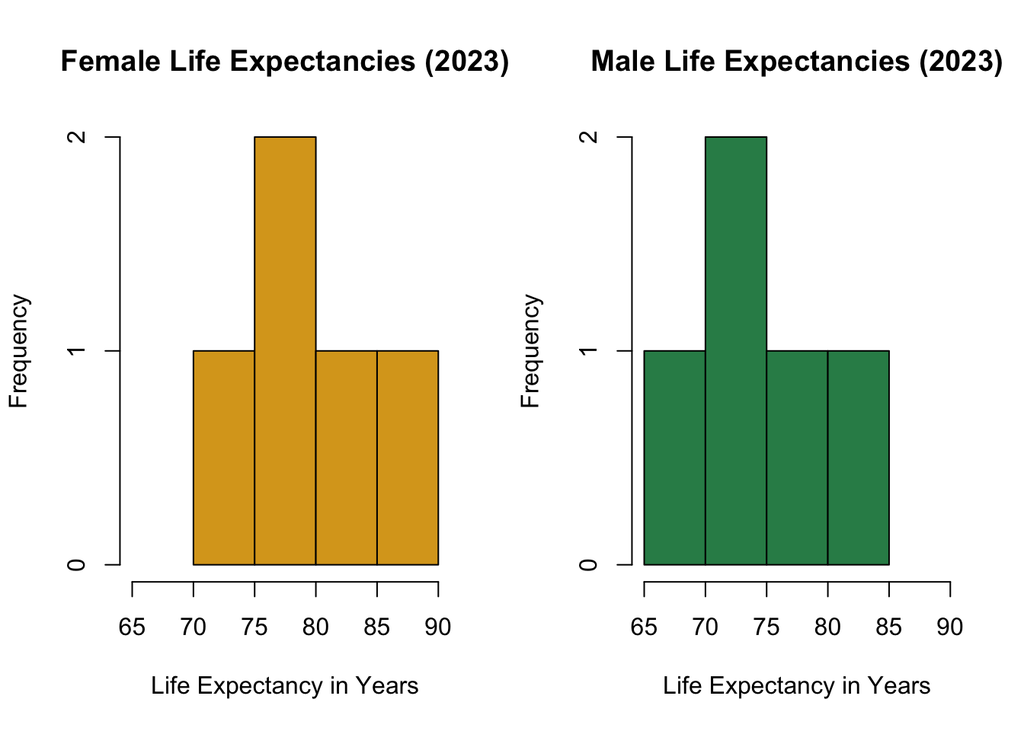

```r
par(mfrow = c(1, 2))

hist(cyclone_data_long_2023$e_0,
  main = "Female Life Expectancies (2023)",
  xlab = "Life Expectancy in Years",
  col = "goldenrod",
  xlim = c(65, 90),
  breaks = 5
)

hist(male_cyclone_long_2023$e_0,
  main = "Male Life Expectancies (2023)",
  xlab = "Life Expectancy in Years",
  col = "seagreen",
  xlim = c(65, 90),
  breaks = 5
)
```

```r
pdf("2023_e0_countrycomparisons.pdf",
    width = 10, height = 6)

par(mfrow = c(1, 2))
barplot(
  cyclone_data_long_2023$e_0,
  names.arg = cyclone_data_long_2023$name,
  main = "Female Life Expectancies (2023)",
  xlab = "Country",
  ylab = "Life Expectancy in Years",
  col = "goldenrod",
  las = 2
)

barplot(
  male_cyclone_long_2023$e_0,
  names.arg = male_cyclone_long_2023$name,
  main = "Male Life Expectancies (2023)",
  xlab = "Country",
  ylab = "Life Expectancy in Years",
  col = "seagreen",
  las = 2
)

dev.off()
```

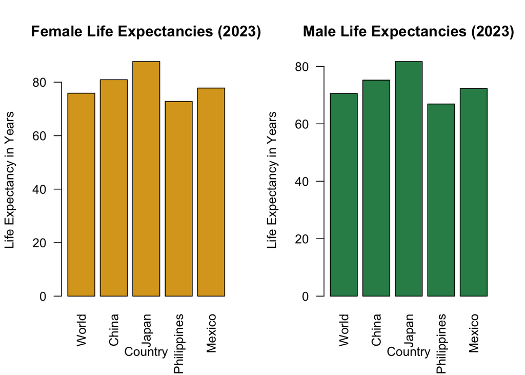

```r
par(mfrow = c(1, 2))
barplot(
  cyclone_data_long_2023$e_0,
  names.arg = cyclone_data_long_2023$name,
  main = "Female Life Expectancies (2023)",
  xlab = "Country",
  ylab = "Life Expectancy in Years",
  col = "goldenrod",
  las = 2
)

barplot(
  male_cyclone_long_2023$e_0,
  names.arg = male_cyclone_long_2023$name,
  main = "Male Life Expectancies (2023)",
  xlab = "Country",
  ylab = "Life Expectancy in Years",
  col = "seagreen",
  las = 2
)
```

**(b)5 points** Create a histogram using `ggplot2` of the male life expectancies and female life expectancies in 2023 that has both histograms side-by-side in a two-panel plot. Show your plot in your output and save it to .pdf. plot in your output and save it to .pdf.

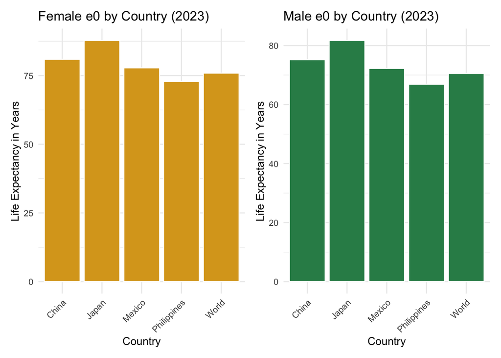

```r
plot1 = ggplot(cyclone_data_long_2023, aes(x = name, y = e_0)) +
  geom_bar(stat = "identity", fill = "goldenrod", color = "white") +
  labs(
    title = "Female e0 by Country (2023)",
    x = "Country",
    y = "Life Expectancy in Years"
  ) +
  theme_minimal() +
  theme(axis.text.x = element_text(angle = 45, hjust = 1))

plot2 = ggplot(male_cyclone_long_2023, aes(x = name, y = e_0)) +
  geom_bar(stat = "identity", fill = "seagreen", color = "white") +
  labs(
    title = "Male e0 by Country (2023)",
    x = "Country",
    y = "Life Expectancy in Years"
  ) +
  theme_minimal() +
  theme(axis.text.x = element_text(angle = 45, hjust = 1))

# Combine the plots with increased space between them
combined_plot = plot1 + plot2 + plot_layout(ncol = 2, widths = c(1, 1))
combined_plot
```

```r
ggsave("cyclone_e0_by_gender_sided.pdf", combined_plot, width = 20, height = 8)
```

**(c)5 points** Create a histogram using `ggplot2` of the male life expectancies and female life expectancies in 2023 that has both female and male life expectancies are presented in the same plot with different colors. Show your plot in your output and save it to .pdf.

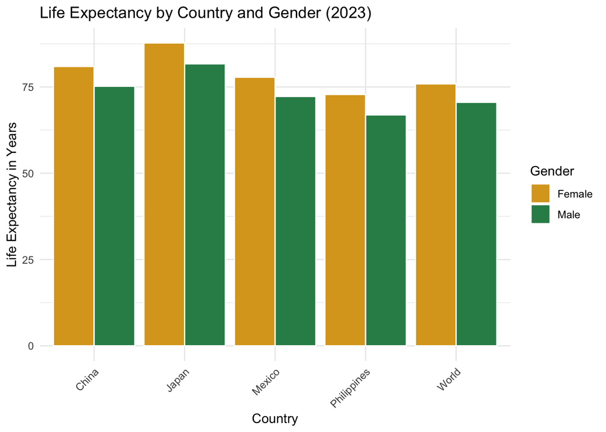

```r
female_data = cyclone_data_long_2023 %>%
  mutate(Gender = "Female")
male_data <- male_cyclone_long_2023 %>%
  mutate(Gender = "Male")

combined_data = bind_rows(female_data, male_data)

ggplot(combined_data, aes(x = name, y = e_0, fill = Gender)) +
  geom_bar(stat = "identity",
           position = "dodge",
           color = "white") +
  labs(
    title = "Life Expectancy by Country and Gender (2023)",
    x = "Country",
    y = "Life Expectancy in Years"
  ) +
  scale_fill_manual(values = c("goldenrod", "seagreen")) +
  theme_minimal() +
  theme(axis.text.x = element_text(angle = 45, hjust = 1))
```

```r
ggsave('cyclone_e0_by_gender_dodge.pdf')
```

# Problem 3: Barplots - 15 points

*Load the dataset `UNlocations` from the `wpp2024` package and read the documentation.*

Description: United Nations table of locations, including regions, for statistical purposes as available in 2024.

Source: Data provided by the United Nations Population Division.

Note: the agcode columns are optional columns that can be used for aggregations. To aggregate a region with country_code=x, get the value of its location_type, say y. Then, look for the column agcode_y and locate all records with agcode_y=x that have location_type=4.

**(a)5 points** Create a barplot in base `R` that has a bar for each region of the world where the height of the bars is the number of countries in that region.

I am assuming the granularity for regions of the world that would best reflect my barplot’s data would be reg_name because it is more granular than area_name. For example, area_name refers to countries in ‘Western Asia’ and ‘South-Eastern Asia’ as just ‘Asia’.

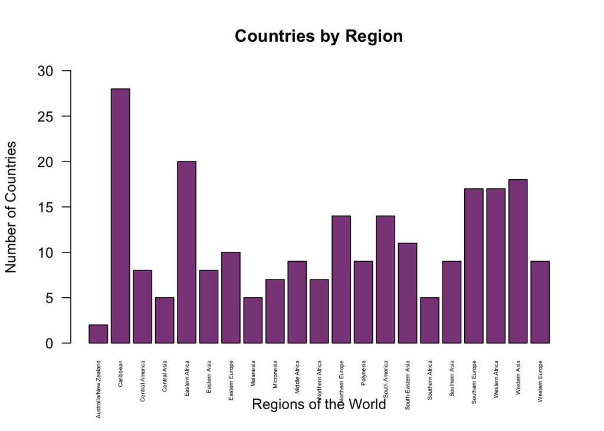

```r
barplot(
  countries_by_area,
  main = "Countries by Region",
  xlab = "Regions of the World",
  ylab = "Number of Countries",
  col = "orchid4",
  # so that the labels all fit
  las = 2,
  # so that they're legible
  cex.names = 0.4,
  # unless the ytick labels will all auto-set to max 25
  ylim = c(0, 30)
)
```

**(b)5 points** Create a barplot in `ggplot2` that has a bar for each region of the world where the height of the bars is the number of countries in that region.

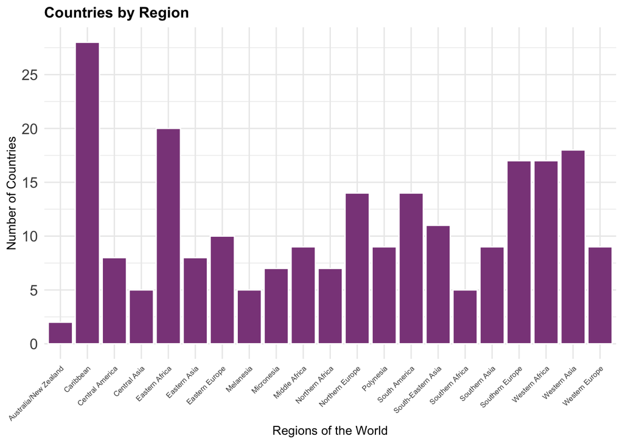

```r
# base R bar plots don't work so well with dataframes but ggplot does
countries_by_area_df <- as.data.frame(countries_by_area)

ggplot(countries_by_area_df, aes(x = Var1, y = Freq)) +
  geom_bar(stat = "identity", fill = "orchid4", color = "white") +
  labs(
    title = "Countries by Region",
    x = "Regions of the World",
    y = "Number of Countries"
  ) +
  theme_minimal() +
  theme(
    axis.text.x = element_text(angle = 45, hjust = 1, vjust = 1, size = 6),
    axis.text.y = element_text(size = 12),
    plot.title = element_text(size = 12, face = "bold"),
    axis.title.x = element_text(size = 10),
    axis.title.y = element_text(size = 10),
    strip.text.x = element_text(size = 10)
  ) +
  scale_y_continuous(breaks = seq(0, 30, by = 5))
```

**(c)5 points** For at least one of the above plots color each bar a different color.

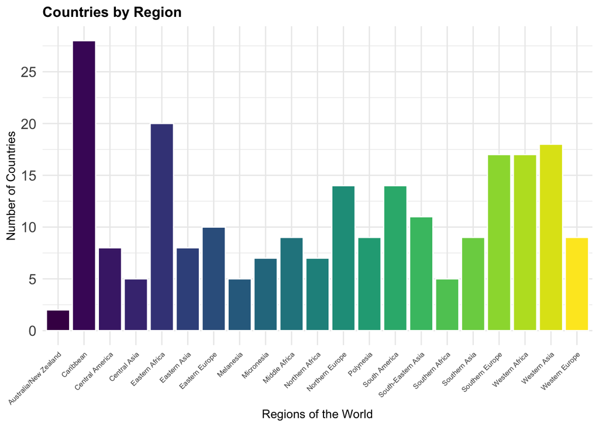

```r
ggplot(countries_by_area_df, aes(x = Var1, y = Freq, fill = Var1)) +
  geom_bar(stat = "identity", color = "white") +
  labs(
    title = "Countries by Region",
    x = "Regions of the World",
    y = "Number of Countries"
  ) +
  theme_minimal() +
  theme(legend.position = "none")  +
  #use this last line to get rid of the legend
  theme(
    axis.text.x = element_text(angle = 45, hjust = 1, vjust = 1, size = 6),
    axis.text.y = element_text(size = 12),
    plot.title = element_text(size = 12, face = "bold"),
    axis.title.x = element_text(size = 10),
    axis.title.y = element_text(size = 10),
    strip.text.x = element_text(size = 10)
  ) +
  scale_y_continuous(breaks = seq(0, 30, by = 5)) +
  # this is the most common one I've been taught and I think it's also color blind accessible
  scale_fill_viridis_d()
```

# Problem 4: Merging Two Datasets - 20 points

*Check out the documentation for the base `R` function `merge` and the dplyr functions `left_join` and `full_join`.*

```
## Help on topic 'merge' was found in the following packages:
##
##   Package               Library
##   base                  /Library/Frameworks/R.framework/Resources/library
##   data.table            /Library/Frameworks/R.framework/Versions/4.4-arm64/Resources/library
##
##
## Using the first match ...
```

Description: Merge two data frames by common columns or row names, or do other versions of database join operations.

Usage: merge(x, y, …)

merge(x, y, by = intersect(names(x), names(y)), by.x = by, by.y = by, all = FALSE, all.x = all, all.y = all, sort = TRUE, suffixes = c(“.x”,“.y”), no.dups = TRUE, incomparables = NULL, …)

Description: Mutating joins add columns from y to x, matching observations based on the keys. There are four mutating joins: the inner join, and the three outer joins.

Inner join: An inner_join() only keeps observations from x that have a matching key in y. This means that generally inner joins are not appropriate in most analyses, because it is too easy to lose observations.

Outer joins: The three outer joins keep observations that appear in at least one of the data frames:

A left_join() keeps all observations in x.

A right_join() keeps all observations in y.

A full_join() keeps all observations in x and y.

left_join( x, y, by = NULL, copy = FALSE, suffix = c(“.x”, “.y”), …, keep = NULL )

left_join( x, y, by = NULL, copy = FALSE, suffix = c(“.x”, “.y”), …, keep = NULL, na_matches = c(“na”, “never”), multiple = “all”, unmatched = “drop”, relationship = NULL )

full_join( x, y, by = NULL, copy = FALSE, suffix = c(“.x”, “.y”), …, keep = NULL )

full_join( x, y, by = NULL, copy = FALSE, suffix = c(“.x”, “.y”), …, keep = NULL, na_matches = c(“na”, “never”), multiple = “all”, relationship = NULL )

**(a)10 points** Use one of these functions to create a new data.frame called `e0` that contains all information from `e0F1` and `e0M1`. Pivot the data.frame longer to create an object called `e0_long` so that there is a new column called `Sex` indicating whether the row contains life expectancies for “Female” or “Male”.

Because the question is asking for all information from `e0F1` and `e0M1` I will use full_join before pivoting.

I am including information about using regex to grab the year columns affected by the pivot by using the following, but not using it in the code below:

1. ^: Matches the start of the string.
2. [0-9]: Matches any digit (0–9).
3. {4}: Matches exactly 4 digits (e.g., 1950, 2023).
4. \.: Matches a literal period (.). The \ is needed to escape the ‘.’ in regex, as ‘.’ is like a wild card and can match any character.
5. (x|y): Matches either x or y. This is a group using the | operator (OR).
6. $: Matches the end of the string.

It’s easier to use the select function because it is convenient, but that is also more hard-coded than using regex, so I’m including it as a comment in the code in case it’s useful to me later.

```r
# Full Join the two dataframes together
e0 <- full_join(e0F1, e0M1, by = "country_code")
e0 = e0 %>% select(-name.y)
e0 = e0 %>% rename(name = name.x)
# e0
```

The reason I chose not to present the entire e0_long dataframe, even with a Kable-style table, is because it is so large that the document fails to render.

```r
e0_long <- e0 %>%
  pivot_longer(
    # cols = matches("^[0-9]{4}\\.(x|y)$") would also work
    cols = -c(country_code, name),
    names_to = c("year", "sex"),
    names_sep = "\\.",
    values_to = "e_0"
  )%>%
  # Map 'x' and 'y' to 'Female' and 'Male'
  mutate(
    sex = ifelse(sex == "x", "Female", "Male")
  )

# nrow(e0_long) #sanity check
for_show = head(e0_long, 51)

#present it
kable(for_show,
      col.names = c("Country Code", "Name", "Year", "Sex" , "Life Expectancy at Birth"),
      digits = 2,
      caption = "Long Format of e0 data in 20th Century: Male & Female Life Expectancy at Birth") %>%
  kable_styling(
    font_size = 15
  ) %>%
  scroll_box(width = "900px", height = "500px")
```

Long Format of e0 data in 20th Century: Male & Female Life Expectancy at Birth

| Country Code | Name | Year | Sex | Life Expectancy at Birth |
| --- | --- | --- | --- | --- |
| 900 | World | 1950 | Female | 48.44 |
| 900 | World | 1951 | Female | 49.04 |
| 900 | World | 1952 | Female | 49.97 |
| 900 | World | 1953 | Female | 50.51 |
| 900 | World | 1954 | Female | 51.33 |
| 900 | World | 1955 | Female | 51.94 |
| 900 | World | 1956 | Female | 52.48 |
| 900 | World | 1957 | Female | 52.82 |
| 900 | World | 1958 | Female | 53.41 |
| 900 | World | 1959 | Female | 51.38 |
| 900 | World | 1960 | Female | 49.60 |
| 900 | World | 1961 | Female | 52.19 |
| 900 | World | 1962 | Female | 55.13 |
| 900 | World | 1963 | Female | 55.62 |
| 900 | World | 1964 | Female | 56.21 |
| 900 | World | 1965 | Female | 56.08 |
| 900 | World | 1966 | Female | 56.57 |
| 900 | World | 1967 | Female | 57.10 |
| 900 | World | 1968 | Female | 57.67 |
| 900 | World | 1969 | Female | 58.06 |
| 900 | World | 1970 | Female | 58.29 |
| 900 | World | 1971 | Female | 58.42 |
| 900 | World | 1972 | Female | 59.31 |
| 900 | World | 1973 | Female | 59.81 |
| 900 | World | 1974 | Female | 60.22 |
| 900 | World | 1975 | Female | 60.48 |
| 900 | World | 1976 | Female | 60.74 |
| 900 | World | 1977 | Female | 61.39 |
| 900 | World | 1978 | Female | 61.80 |
| 900 | World | 1979 | Female | 62.49 |
| 900 | World | 1980 | Female | 62.87 |
| 900 | World | 1981 | Female | 63.34 |
| 900 | World | 1982 | Female | 63.80 |
| 900 | World | 1983 | Female | 63.97 |
| 900 | World | 1984 | Female | 64.33 |
| 900 | World | 1985 | Female | 64.66 |
| 900 | World | 1986 | Female | 65.17 |
| 900 | World | 1987 | Female | 65.65 |
| 900 | World | 1988 | Female | 65.83 |
| 900 | World | 1989 | Female | 66.26 |
| 900 | World | 1990 | Female | 66.43 |
| 900 | World | 1991 | Female | 66.53 |
| 900 | World | 1992 | Female | 66.80 |
| 900 | World | 1993 | Female | 67.00 |
| 900 | World | 1994 | Female | 66.93 |
| 900 | World | 1995 | Female | 67.45 |
| 900 | World | 1996 | Female | 67.73 |
| 900 | World | 1997 | Female | 68.03 |
| 900 | World | 1998 | Female | 68.23 |
| 900 | World | 1999 | Female | 68.53 |
| 900 | World | 2000 | Female | 68.92 |

**(b)5 points** Pick one country from those available and make a new data.frame called `e0.small` that contains only rows with data from those country.

I am choosing Cambodia with country code = 116. I read a paper in the previous demography-track course on new methodology for estimating excess deaths during the PPR (Pol Pot Regime). Those researchers used survivor interviews, satellite imagery from mass graves, and voter records, among other avenues, to make an educated guess. I don’t have any experience seeing how this affects aggregate life expectancy data so I thought this would be a good opportunity to learn.

```r
e0_small = e0_long %>%
  filter(country_code == 116)

# dim(e0_small)
# e0_small

kable(e0_small,
      col.names = c("Country Code", "Name", "Year", "Sex" , "Life Expectancy at Birth"),
      digits = 2,
      caption = "Long Format of Male & Female Life Expectancy at Birth in Cambodia") %>%
  kable_styling(
    font_size = 15
  ) %>%
  scroll_box(width = "900px", height = "500px")
```

Long Format of Male & Female Life Expectancy at Birth in Cambodia

| Country Code | Name | Year | Sex | Life Expectancy at Birth |
| --- | --- | --- | --- | --- |
| 116 | Cambodia | 1950 | Female | 39.60 |
| 116 | Cambodia | 1951 | Female | 39.87 |
| 116 | Cambodia | 1952 | Female | 40.21 |
| 116 | Cambodia | 1953 | Female | 40.47 |
| 116 | Cambodia | 1954 | Female | 40.76 |
| 116 | Cambodia | 1955 | Female | 41.16 |
| 116 | Cambodia | 1956 | Female | 41.40 |
| 116 | Cambodia | 1957 | Female | 41.80 |
| 116 | Cambodia | 1958 | Female | 42.15 |
| 116 | Cambodia | 1959 | Female | 42.67 |
| 116 | Cambodia | 1960 | Female | 43.23 |
| 116 | Cambodia | 1961 | Female | 43.77 |
| 116 | Cambodia | 1962 | Female | 44.34 |
| 116 | Cambodia | 1963 | Female | 44.89 |
| 116 | Cambodia | 1964 | Female | 45.42 |
| 116 | Cambodia | 1965 | Female | 45.94 |
| 116 | Cambodia | 1966 | Female | 46.45 |
| 116 | Cambodia | 1967 | Female | 47.05 |
| 116 | Cambodia | 1968 | Female | 47.45 |
| 116 | Cambodia | 1969 | Female | 47.90 |
| 116 | Cambodia | 1970 | Female | 47.38 |
| 116 | Cambodia | 1971 | Female | 47.64 |
| 116 | Cambodia | 1972 | Female | 47.91 |
| 116 | Cambodia | 1973 | Female | 47.97 |
| 116 | Cambodia | 1974 | Female | 48.17 |
| 116 | Cambodia | 1975 | Female | 15.22 |
| 116 | Cambodia | 1976 | Female | 13.14 |
| 116 | Cambodia | 1977 | Female | 12.75 |
| 116 | Cambodia | 1978 | Female | 13.37 |
| 116 | Cambodia | 1979 | Female | 49.96 |

[output cut: 118 more lines]

**(c)5 points** Plot the male and female trajectories of life expectancy for that country using base `R` and `ggplot2`, using either color or line type to distinguish between the trajectories.

Base R plotting code:

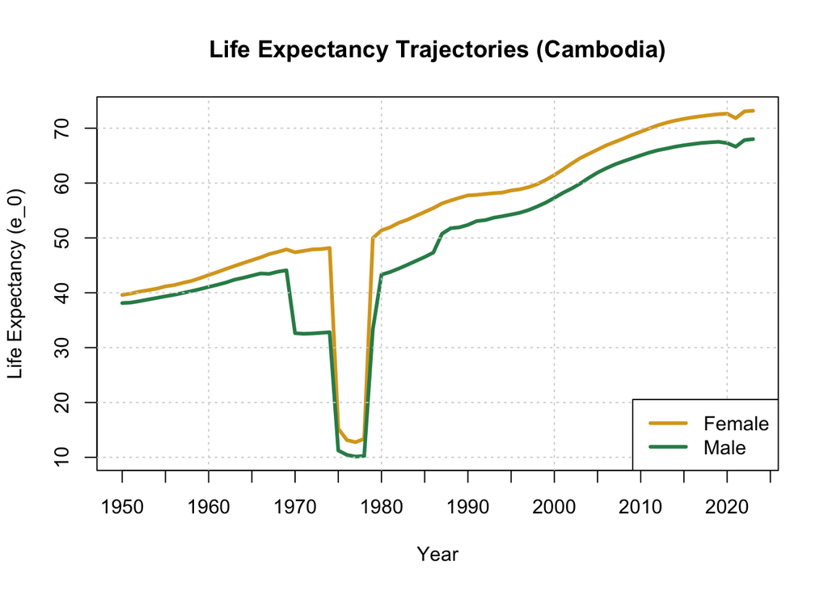

```r
cambodia_longF = e0_small[e0_small$sex == "Female", ]
cambodia_longM <- e0_small[e0_small$sex == "Male", ]

plot(cambodia_longF$year, cambodia_longF$e_0,
     type = "l",
     col = "goldenrod",
     lwd = 3,
     xlab = "Year",
     ylab = "Life Expectancy (e_0)",
     main = "Life Expectancy Trajectories (Cambodia)",
     ylim = range(e0_small$e_0),
     xaxt = "n")

years = seq(1950, 2025, by = 5)
axis(1, at = years, labels = years)

lines(cambodia_longM$year, cambodia_longM$e_0,
      col = "seagreen",
      lwd = 3)

#grid lines
grid(nx = NULL, ny = NULL, col = "lightgray")

legend("bottomright",
       legend = c("Female", "Male"),
       col = c("goldenrod", "seagreen"),
       lwd = 3)
```

ggplot2 plotting code:

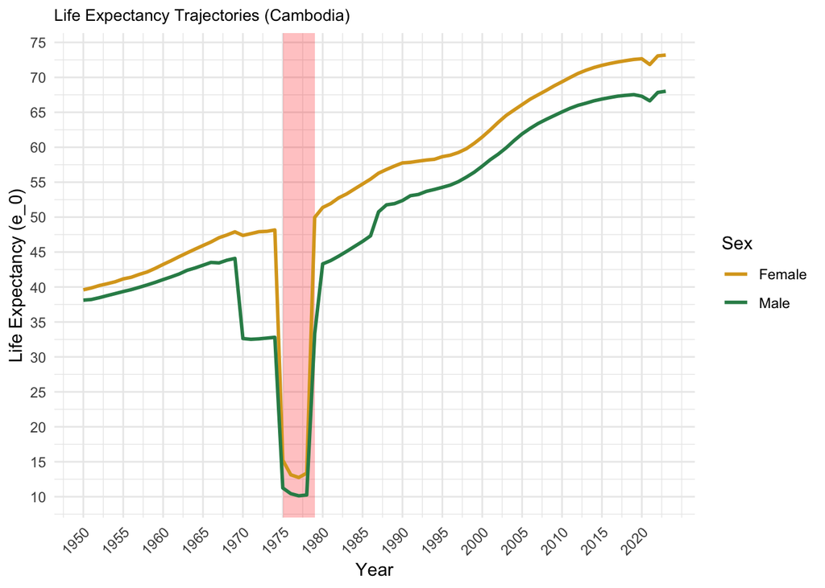

```r
e0_small$year = as.numeric(e0_small$year)

ggplot(e0_small, aes(x = year, y = e_0, color = sex)) +
  annotate("rect", xmin = 1975, xmax = 1979, ymin = -Inf, ymax = Inf,
           fill = "red", alpha = 0.25) +
  geom_line(size = 1) +
  labs(
    title = "Life Expectancy Trajectories (Cambodia)",
    x = "Year",
    y = "Life Expectancy (e_0)",
    color = "Sex"
  ) +
  scale_color_manual(
    values = c("Female" = "goldenrod", "Male" = "seagreen")
  ) +
  scale_x_continuous(breaks = seq(min(e0_small$year), max(e0_small$year), by = 5)) +
  scale_y_continuous(breaks = seq(0, 80, by = 5)) +
  theme_minimal() +
  theme(
    plot.title = element_text(size = 10),
    axis.text.x = element_text(angle = 45, hjust = 1)
  )
```

The PPR period lasted from 1975-1979.